# Unsupervised Methods: Clustering Analyses

W. McDonald

11/10/2019

## Data import

```r
library(tidyverse)
patma <- read_csv("data/TpitAddedVillaUpdate.csv")
# Get rid of the Note column
patma <- patma[-30]
glimpse(patma)
```

```
## Observations: 157
## Variables: 29
## $ CaseID        <dbl> 1, 2, 3, 4, 5, 6, 7, 8, 9, 10, 11, 12, 13, 14, 15, 16, …
## $ Dx            <chr> "PRL", "GON", "GON", "GON", "PRL", "GON", "TSH+", "GON"…
## $ SurgPathNo    <chr> "US07-15157", "US08-2344", "AS08-5683", "US08-5441", "U…
## $ Pit1Median    <dbl> 8.0, 0.0, 0.0, 0.0, 8.0, 0.0, 8.0, 0.0, 0.0, 0.0, 3.0, …
## $ SF1Median     <dbl> 0.0, 8.0, 5.0, 8.0, 0.0, 8.0, 0.0, 8.0, 8.0, 0.0, 8.0, …
## $ ASUMedian     <dbl> 0.0, 0.0, 0.0, 0.0, 0.0, 6.5, 7.0, 0.0, 4.0, 0.0, 6.0, …
## $ PRLMedian     <dbl> 8.0, 0.0, 0.0, 0.0, 8.0, 0.0, 1.5, 0.0, 0.0, 0.0, 0.0, …
## $ GHMedian      <dbl> 0.0, 0.0, 0.0, 0.0, 0.0, 0.0, 4.0, 0.0, 0.0, 0.0, 0.0, …
## $ ACTHMedian    <dbl> 0, 0, 0, 0, 0, 0, 0, 0, 0, 0, 0, 0, 0, 7, 0, 0, 0, 0, 0…
## $ FSHMedian     <dbl> 0.0, 0.0, 0.0, 0.0, 0.0, 7.0, 0.0, 0.0, 3.5, 0.0, 2.5, …
## $ LHMedian      <dbl> 0.0, 0.0, 0.0, 0.0, 0.0, 1.5, 0.0, 0.0, 1.0, 0.0, 2.5, …
## $ TSHMedian     <dbl> 0, 0, 0, 0, 0, 0, 8, 0, 0, 0, 0, 0, 0, 0, 0, 0, 0, 0, 0…
## $ CAM52Median   <dbl> 0.0, 0.0, 0.0, 0.0, 0.0, 0.0, 0.0, 0.0, 0.0, 0.0, 1.5, …
```

[output cut: 16 more lines]

# Clustering analyses

## Hierarchical clustering

Note that the hierarchical clustering profits from name transparency when producing the final plot. The first bits of code make an object that has lost newDx and CaseID in favor of a row name that bears a combination of the two.

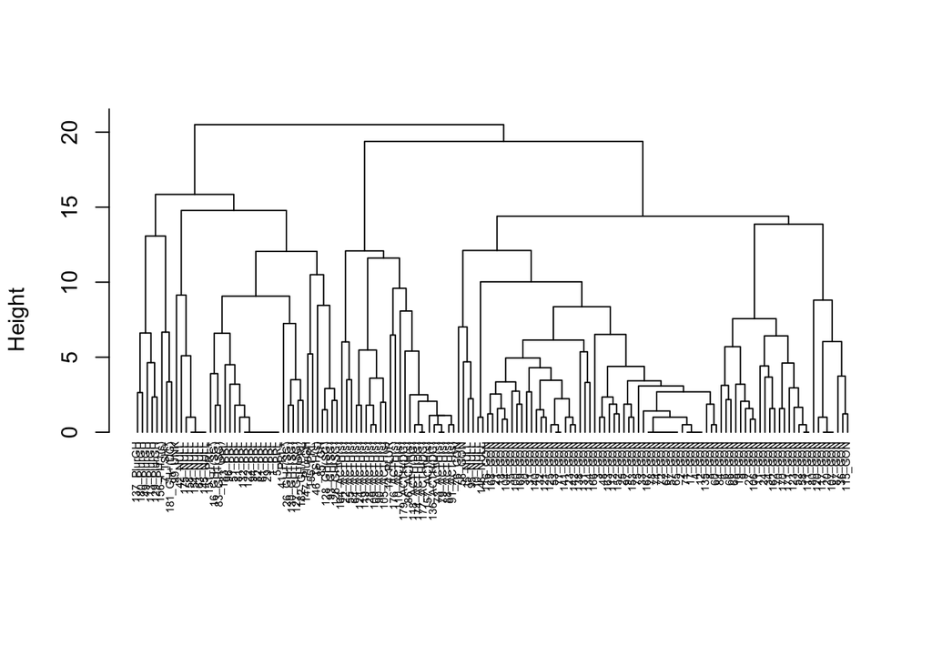

```r
rowsAssigned <- patma %>%
  unite("RowNames", c("CaseID", "finDx")) %>%
  column_to_rownames(var = "RowNames")

df <- rowsAssigned %>%
  select(SF1Median, Pit1Median, TPITMedian, PRLMedian, GHMedian, TSHMedian, LHMedian, FSHMedian, ACTHMedian, ASUMedian, GATA3Median) %>%
  na.omit()

d <- dist(df, method = "euclidean")

hc1 <- hclust(d, method = "complete")

plot(hc1,
     main = "", # As an alternative: main = "Hierarchical Clustering",
     xlab = "",
     sub = "",
     cex.sub = 1.5,
     cex = 0.5,
     #      cex.main = 2, #this doesn't matter since the label is supressed in line 100 with main = ""
     pty = "m",
     hang = -2)
```

## K-means cluster analysis and display using clusplot()

Two things are recommended when performing K-means clustering: assign a large nstart and using the setseed() function

```r
set.seed(2019)
rowsAssigned <- patma %>%
  unite("RowNames", c("CaseID", "finDx")) %>%
  column_to_rownames(var = "RowNames")

km6 <- rowsAssigned %>%
  select(SF1Median, Pit1Median, TPITMedian, PRLMedian, GHMedian, TSHMedian, LHMedian, FSHMedian, ACTHMedian) %>%
  na.omit() %>%
  kmeans(6,nstart=20)

glimpse(km6)
```

```
## List of 9
##  $ cluster     : Named int [1:147] 2 4 4 4 2 1 6 4 1 3 ...
##   ..- attr(*, "names")= chr [1:147] "1_PRL" "2_GON" "3_GON" "4_GON" ...
##  $ centers     : num [1:6, 1:9] 7.673 0.19 0.154 7.429 0.375 ...
##   ..- attr(*, "dimnames")=List of 2
##   .. ..$ : chr [1:6] "1" "2" "3" "4" ...
##   .. ..$ : chr [1:9] "SF1Median" "Pit1Median" "TPITMedian" "PRLMedian" ...
##  $ totss       : num 8062
##  $ withinss    : num [1:6] 179 163 113 196 399 ...
##  $ tot.withinss: num 1482
##  $ betweenss   : num 6580
##  $ size        : int [1:6] 26 21 13 49 24 14
##  $ iter        : int 3
##  $ ifault      : int 0
##  - attr(*, "class")= chr "kmeans"
```

```r
str(km6)
```

```
## List of 9
##  $ cluster     : Named int [1:147] 2 4 4 4 2 1 6 4 1 3 ...
##   ..- attr(*, "names")= chr [1:147] "1_PRL" "2_GON" "3_GON" "4_GON" ...
##  $ centers     : num [1:6, 1:9] 7.673 0.19 0.154 7.429 0.375 ...
##   ..- attr(*, "dimnames")=List of 2
##   .. ..$ : chr [1:6] "1" "2" "3" "4" ...
##   .. ..$ : chr [1:9] "SF1Median" "Pit1Median" "TPITMedian" "PRLMedian" ...
##  $ totss       : num 8062
##  $ withinss    : num [1:6] 179 163 113 196 399 ...
##  $ tot.withinss: num 1482
##  $ betweenss   : num 6580
##  $ size        : int [1:6] 26 21 13 49 24 14
##  $ iter        : int 3
##  $ ifault      : int 0
##  - attr(*, "class")= chr "kmeans"
```

```r
km6$cluster %>% sort()
```

```
##        6_GON        9_GON       11_GON       19_GON       21_GON       24_GON
##            1            1            1            1            1            1
##       27_GON       32_GON       34_GON       36_GON       52_GON       58_GON
##            1            1            1            1            1            1
##       66_GON       68_GON       70_GON       84_GON       87_GON      106_GON
##            1            1            1            1            1            1
##      111_GON      115_GON      121_GON      123_GON      134_GON      162_GON
##            1            1            1            1            1            1
##      170_GON      171_GON        1_PRL        5_PRL   16_GH+(SG)   26_GH+(SG)
##            1            1            2            2            2            2
##       29_PRL      41_PRL+       51_PRL       61_PRL       81_PRL       82_PRL
##            2            2            2            2            2            2
##   83_GH+(SG)       94_PRL       96_PRL      122_PRL  127_GH+(SG)  130_GH+(SG)
##            2            2            2            2            2            2
##      132_PRL     151_PRL+      155_PRL   182_GH/PRL      183_PRL      10_NULL
##            2            2            2            2            2            3
##      15_NULL      42_NULL       56_GON      63_NULL       76_GON      95_NULL
##            3            3            3            3            3            3
##       99_UNK     145_NULL     146_NULL     154_NULL     158_NULL     175_NULL
##            3            3            3            3            3            3
##        2_GON        3_GON        4_GON        8_GON       12_GON       17_GON
##            4            4            4            4            4            4
##       18_GON       20_GON       23_GON       25_GON       30_GON       31_GON
##            4            4            4            4            4            4
##       33_GON       35_GON       48_GON       53_GON       57_GON       60_GON
##            4            4            4            4            4            4
##       65_GON       67_GON       71_GON       72_GON       74_GON       75_GON
##            4            4            4            4            4            4
##       77_GON       78_GON       80_GON       97_GON      100_GON      104_GON
##            4            4            4            4            4            4
##      107_GON      112_GON      116_GON      117_GON      120_GON      125_GON
##            4            4            4            4            4            4
##      131_GON      135_GON      138_GON      140_GON      141_GON      142_GON
##            4            4            4            4            4            4
##      152_GON      153_GON      163_GON      166_GON      167_GON      168_GON
##            4            4            4            4            4            4
##      169_GON      14_PLUR   22_ACTH(s)   28_ACTH(s)   55_ACTH(s)   64_ACTH(s)
##            4            5            5            5            5            5
##   73_ACTH(s)   79_ACTH(s)   86_ACTH(s)   88_ACTH(s)   90_ACTH(s)   91_ACTH(s)
##            5            5            5            5            5            5
##  105_ACTH(s)  109_ACTH(s)  110_ACTH(s) 118_ACTH(DG)  119_ACTH(s)  124_ACTH(s)
##            5            5            5            5            5            5
## 136_ACTH(DG)  157_ACTH(s)  164_ACTH(s) 174_ACTH(DG)  176_ACTH(s) 177_ACTH(DG)
##            5            5            5            5            5            5
## 179_ACTH(DG)       7_TSH+    46_TSH(s)    49_PlurGH        85_GH    93_GH(SG)
##            5            6            6            6            6            6
##   113_PlurGH   126_GH(SG)   128_GH(SG)   129_PlurGH   137_PlurGH   147_PlurGH
##            6            6            6            6            6            6
##  156_PIT1(s)   180_PlurGH  181_GH+(DG)
##            6            6            6
```

Let’s try this again starting with ideas from the DataCamp course by Hank Roark:

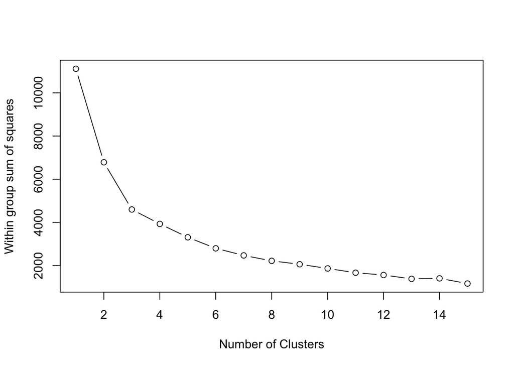

```r
rowsAssigned <- patma %>%
  unite("RowNames", c("CaseID", "finDx")) %>%
  column_to_rownames(var = "RowNames")

df <- rowsAssigned %>%
  select(SF1Median, Pit1Median, TPITMedian, PRLMedian, GHMedian, TSHMedian, LHMedian, FSHMedian, ACTHMedian, ASUMedian, GATA3Median) %>%
  na.omit()

wss <- 0

for (i in 1:15) {
  km.out <- kmeans(df, centers = i, nstart = 20, iter.max = 50)
  wss[i] <- km.out$tot.withinss
}

plot(1:15, wss, type = "b",
     xlab = "Number of Clusters",
     ylab = "Within group sum of squares")
```

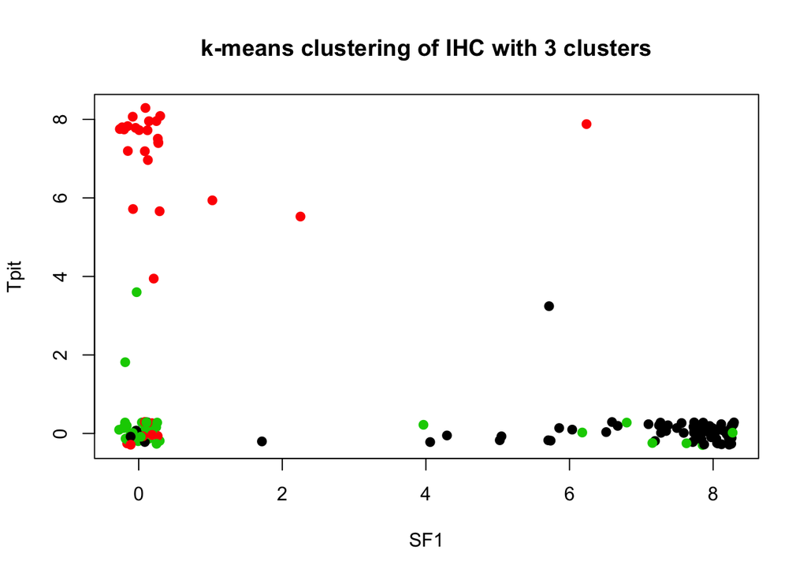

```r
k <- 3

km.out <- kmeans(df, centers = 3, nstart = 20, iter.max = 50)

plot(jitter(df$SF1Median, 3), jitter(df$TPITMedian, 3),
     pch = 19,
     col = km.out$cluster,
     main = paste("k-means clustering of IHC with", k, "clusters"),
     xlab = "SF1",
     ylab = "Tpit")
```

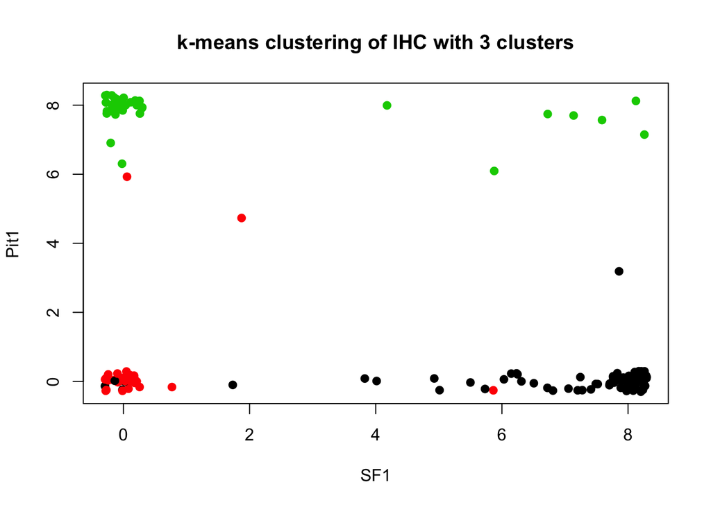

```r
plot(jitter(df$SF1Median, 3), jitter(df$Pit1Median, 3),
     pch = 19,
     col = km.out$cluster,
     main = paste("k-means clustering of IHC with", k, "clusters"),
     xlab = "SF1",
     ylab = "Pit1")
```

## Comparing hierarchical clustering and k-means clustering

The DataCamp course on unsupervised clustering by Hank Roark showed a very nice way to compare hierarchical and k-means clustering. He also stressed the value of normalization, even for those things on the same scale, since mean and standard deviation can vary greatly between features (that is, variables).

```r
df <-  patma %>%
  select(SF1Median, Pit1Median, TPITMedian, PRLMedian, GHMedian, TSHMedian, LHMedian, FSHMedian, ACTHMedian, ASUMedian, GATA3Median) %>%
  na.omit()

df_scaled <- scale(df)

hclust.df <- hclust(dist(df_scaled), method = "complete")
km.df <- kmeans(df_scaled,
                centers = 3,
                nstart = 20,
                iter.max = 50)
cut.df <- cutree(hclust.df, k = 3)

table(km.df$cluster, cut.df)
```

```
##    cut.df
##      1  2  3
##   1  0 51 36
##   2  0 24  0
##   3 36  0  0
```

Ultimately, if one uses 3 groups, the two models agree perfectly in 96/147 (65%) of cases.

## Principle component analysis (PCA)

Work in progress: check out [this site for some good techniques](http://huboqiang.cn/2016/03/03/RscatterPlotPCA).

See also [this page](https://community.rstudio.com/t/tidyverse-solutions-for-factor-analysis-principal-component-analysis/4504).

PCA using tidyverse tools requires a little different method. See [this work](https://tbradley1013.github.io/2018/02/01/pca-in-a-tidy-verse-framework/) by Tyler Bradley.

```r
pc <- patma %>%
  select(SF1Median, Pit1Median, TPITMedian, PRLMedian, GHMedian, TSHMedian, LHMedian, FSHMedian, ACTHMedian) %>%
  na.omit() %>%
  prcomp(center = TRUE, scale = FALSE)

summary(pc) # these list the principle components in decending explanatory ability. See proporation of overall variance.
```

```
## Importance of components:
##                           PC1    PC2   PC3     PC4     PC5     PC6     PC7
## Standard deviation     4.9378 3.9703 2.075 1.94297 1.62924 1.19883 1.10400
## Proportion of Variance 0.4415 0.2854 0.078 0.06836 0.04807 0.02603 0.02207
## Cumulative Proportion  0.4415 0.7270 0.805 0.87333 0.92140 0.94743 0.96950
##                            PC8     PC9
## Standard deviation     1.04123 0.77466
## Proportion of Variance 0.01963 0.01087
## Cumulative Proportion  0.98913 1.00000
```

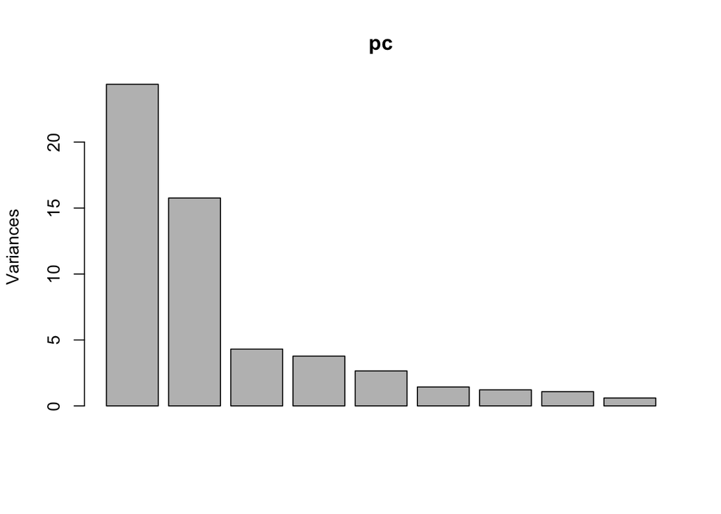

```r
plot(pc) # how many components do you want to include? No set answer
```

```r
pc # rotation section lets us know the relationship between IHC and principle components
```

```
## Standard deviations (1, .., p=9):
## [1] 4.9377906 3.9702544 2.0754206 1.9429736 1.6292382 1.1988262 1.1040006
## [8] 1.0412331 0.7746647
##
## Rotation (n x k) = (9 x 9):
##                    PC1         PC2        PC3         PC4         PC5
## SF1Median   0.64617167 -0.38352062 -0.2921897  0.51321864 -0.20636689
## Pit1Median -0.56777436 -0.41483524 -0.2622298  0.24425170  0.08450969
## TPITMedian -0.12104782  0.61640862 -0.1979050  0.28741850  0.03896383
## PRLMedian  -0.40137576 -0.25189428  0.4327592  0.48693000 -0.09073467
## GHMedian   -0.18340707 -0.17774764 -0.6268734 -0.13357332  0.10480554
## TSHMedian  -0.08212915 -0.05659444 -0.3774182 -0.23257865  0.11998343
## LHMedian    0.11516273 -0.05602509  0.0195544  0.15274478  0.37844932
## FSHMedian   0.15721479 -0.06924371  0.1388428  0.09525061  0.87779672
## ACTHMedian -0.07731160  0.44122861 -0.2536520  0.50289085  0.03726491
##                     PC6         PC7          PC8         PC9
## SF1Median   0.081775900 -0.18994067  0.004284806  0.03515024
## Pit1Median -0.052826845 -0.03435113 -0.040862617  0.60360443
## TPITMedian  0.035393420 -0.60135482 -0.341954130  0.04775919
## PRLMedian   0.200032472 -0.12159463 -0.003923912 -0.53667403
## GHMedian   -0.429848315 -0.06589831 -0.001097174 -0.56908520
## TSHMedian   0.873592116  0.01017416  0.018810572 -0.12449093
## LHMedian    0.006912892  0.45003152 -0.781088247 -0.06313875
## FSHMedian  -0.028560764 -0.23887109  0.337196910  0.00590381
## ACTHMedian  0.021449439  0.56771102  0.396494913 -0.02736601
```

```r
predict(pc)
```

```
##               PC1         PC2          PC3         PC4          PC5
##   [1,] -8.7031140 -3.48531430  3.552078294  1.84752956 -0.397011394
##   [2,]  4.2194603 -1.21964307 -0.149673753  0.10382504 -1.998146653
##   [3,]  2.2809453 -0.06908121  0.726895204 -1.43583088 -1.379045990
##   [4,]  4.2194603 -1.21964307 -0.149673753  0.10382504 -1.998146653
##   [5,] -8.7031140 -3.48531430  3.552078294  1.84752956 -0.397011394
##   [6,]  5.4927080 -1.78838667  0.851557772  0.99969646  4.714104344
##   [7,] -7.4848330 -3.01174754 -4.787695586 -3.71243792  1.571853512
##   [8,]  4.2194603 -1.21964307 -0.149673753  0.10382504 -1.998146653
##   [9,]  4.8848748 -1.51802114  0.355830609  0.58994695  1.452591175
##  [10,] -0.9499130  1.84852189  2.187843465 -4.00192407 -0.347211553
##  [11,]  3.1970811 -2.77732078 -0.540370138  1.45656862  1.395997492
##  [12,]  4.2194603 -1.21964307 -0.149673753  0.10382504 -1.998146653
##  [13,] -5.8676141  3.93792871 -2.687252373  4.94836196  0.054017096
##  [14,] -0.9499130  1.84852189  2.187843465 -4.00192407 -0.347211553
```

[output cut: 281 more lines]

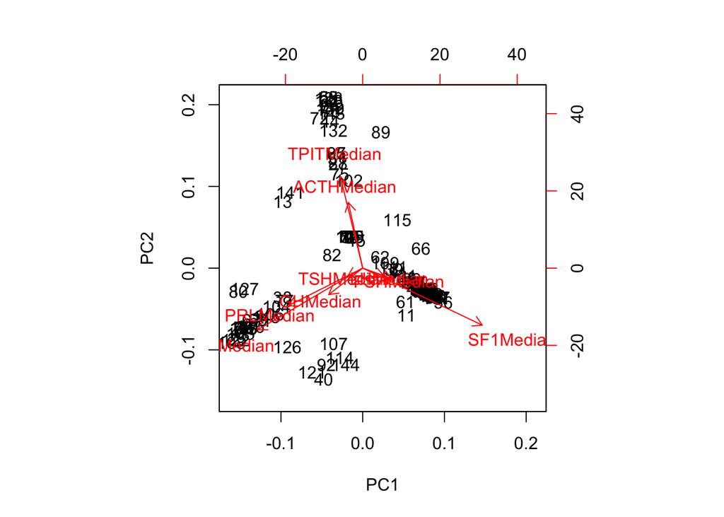

```r
biplot(pc) # VERY interesting in its ability to distinguish between the Pit1, SF1 and Tpit groups
```

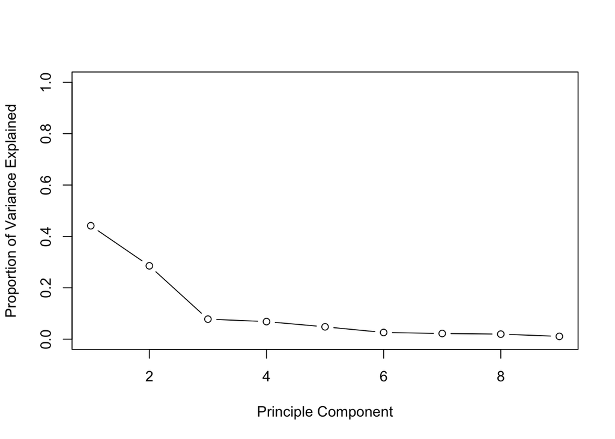

```r
# Scree plots are also useful, and common.

pr.var <- pc$sdev^2
pve <- pr.var/sum(pr.var)
plot(pve, xlab = "Principle Component",
     ylab = "Proportion of Variance Explained",
     ylim = c(0,1), type = "b")
```

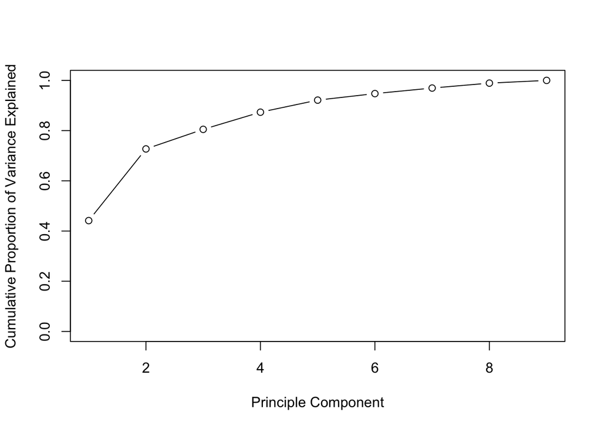

```r
plot(cumsum(pve), xlab = "Principle Component",
     ylab = "Cumulative Proportion of Variance Explained",
     ylim = c(0,1), type = "b")
```

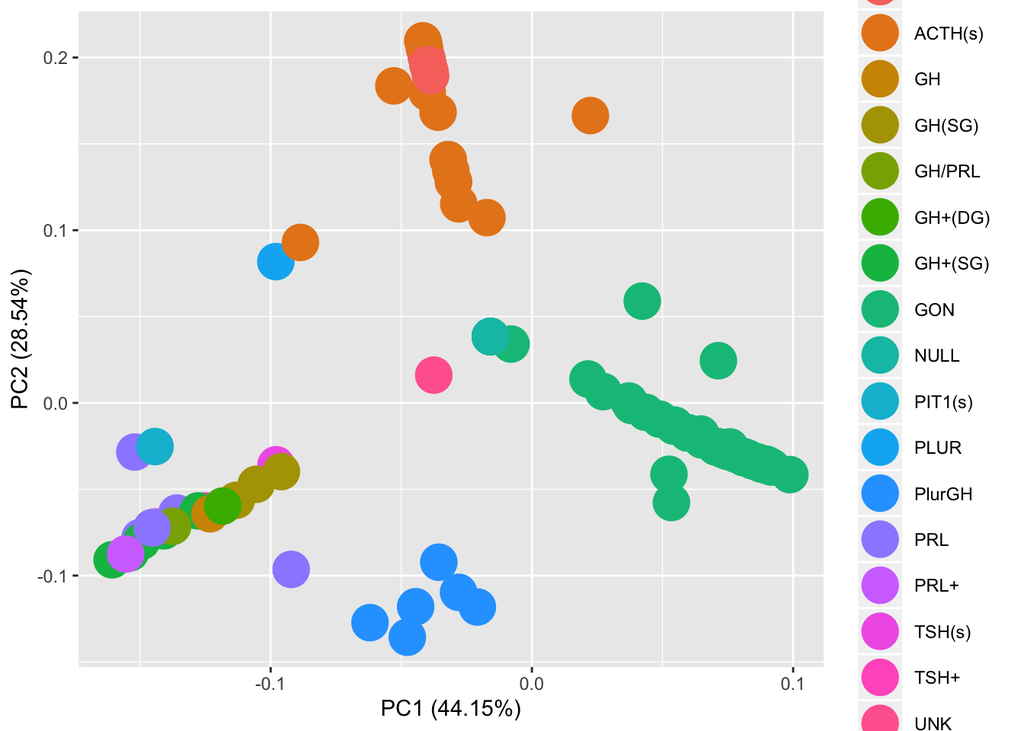

```r
library(ggfortify)
df <- patma %>%
  select(SF1Median, Pit1Median, TPITMedian, PRLMedian, GHMedian, TSHMedian, LHMedian, FSHMedian, ACTHMedian) %>%
  na.omit()

trimmedSet <- patma %>%
  select(SF1Median, Pit1Median, TPITMedian, PRLMedian, GHMedian, TSHMedian, LHMedian, FSHMedian, ACTHMedian, finDx) %>%
  na.omit()

# Try fct_lumping the trimmed set so that the principle component display doesn't look so busy. See GATA3 code to see how I did it then.

autoplot(prcomp(df), data = trimmedSet, colour = 'finDx', size = 8)
```

Notes on the scaling of PCA: it’s interesting to compare scale = TRUE and scale = FALSE biplots of the PCA data. While scaling may erase differences in mean and SD of IHC scores, but not change the vector direction, NOT scaling allows the principle drivers of the classification to be clear: SF1, Tpit, and Pit-1. Consider displaying both of these.

Consider adding ASU, GATA3, ER, etc. into the model and studying the vectors. Can this be used to pick features?

## T-SNE (t-Distributed Stochastic Neighbor Embedding) analysis

This is an interesting method that is usually compared with PCA plots. See [this page](https://stackoverflow.com/questions/44837536/how-to-use-ggplot-to-plot-t-sne-clustering).

DataCamp has a tutorial for python that describes T-SNE at [this page](https://www.datacamp.com/community/tutorials/introduction-t-sne).

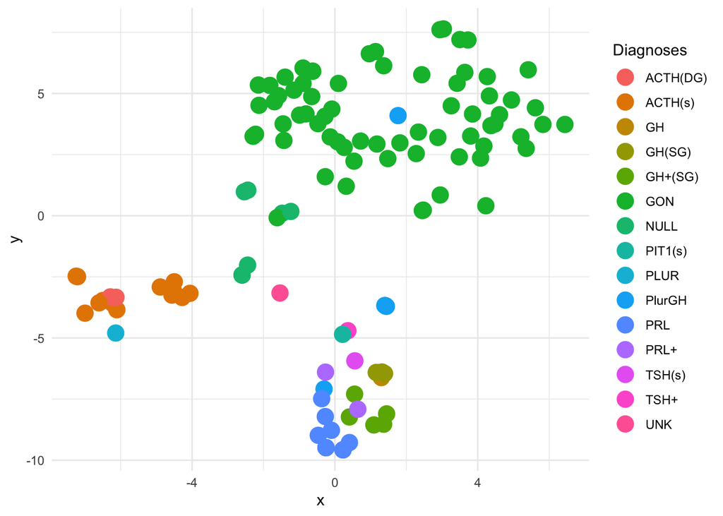

```r
library(Rtsne)
patma_unique <- patma %>%
  na.omit() %>%
  unique()

patma_matrix <- as.matrix(patma_unique[,c(4:12, 18, 23, 24)])

set.seed(2019)
tsne_out <- Rtsne(patma_matrix, check_duplicates = FALSE, theta = 0.0)

library(ggplot2)
tsne_plot <- data.frame(x = tsne_out$Y[,1], y = tsne_out$Y[,2], Diagnoses = patma_unique$finDx)

ggplot(tsne_plot) +
  geom_point(aes(x=x, y=y, color=Diagnoses), size = 5) +
  theme_minimal()
```

Note that I removed column 30 from this version of patma: the NA’s played havoc with the Rtsne procedure (the na.omit struck all cases without a note). I need to be on the lookout for similar problems using this set.

## Factor analysis

Easy to do. Hard to interpret. Explain these.

```r
df <- patma %>%
  select(SF1Median, Pit1Median, TPITMedian, PRLMedian, GHMedian, TSHMedian, LHMedian, FSHMedian, ACTHMedian) %>%
  na.omit()

factanal(df, 1)
```

```
##
## Call:
## factanal(x = df, factors = 1)
##
## Uniquenesses:
##  SF1Median Pit1Median TPITMedian  PRLMedian   GHMedian  TSHMedian   LHMedian
##      0.797      0.005      0.962      0.384      0.578      0.892      0.945
##  FSHMedian ACTHMedian
##      0.925      0.978
##
## Loadings:
##            Factor1
## SF1Median  -0.451
## Pit1Median  0.998
## TPITMedian -0.196
## PRLMedian   0.785
## GHMedian    0.649
## TSHMedian   0.329
## LHMedian   -0.233
## FSHMedian  -0.274
## ACTHMedian -0.147
##
##                Factor1
## SS loadings      2.533
## Proportion Var   0.281
##
## Test of the hypothesis that 1 factor is sufficient.
## The chi square statistic is 347.94 on 27 degrees of freedom.
## The p-value is 1.78e-57
```

```r
factanal(df, 2)
```

```
##
## Call:
## factanal(x = df, factors = 2)
##
## Uniquenesses:
##  SF1Median Pit1Median TPITMedian  PRLMedian   GHMedian  TSHMedian   LHMedian
##      0.473      0.005      0.023      0.384      0.578      0.892      0.876
##  FSHMedian ACTHMedian
##      0.846      0.389
##
## Loadings:
##            Factor1 Factor2
## SF1Median  -0.445  -0.574
## Pit1Median  0.997
## TPITMedian -0.208   0.966
## PRLMedian   0.785
## GHMedian    0.649
## TSHMedian   0.328
## LHMedian   -0.231  -0.266
## FSHMedian  -0.271  -0.284
## ACTHMedian -0.156   0.766
##
##                Factor1 Factor2
## SS loadings      2.533   2.003
## Proportion Var   0.281   0.223
## Cumulative Var   0.281   0.504
##
## Test of the hypothesis that 2 factors are sufficient.
## The chi square statistic is 127.28 on 19 degrees of freedom.
## The p-value is 4.77e-18
```

```r
factanal(df, 3)
```

```
##
## Call:
## factanal(x = df, factors = 3)
##
## Uniquenesses:
##  SF1Median Pit1Median TPITMedian  PRLMedian   GHMedian  TSHMedian   LHMedian
##      0.451      0.039      0.018      0.046      0.272      0.725      0.867
##  FSHMedian ACTHMedian
##      0.837      0.391
##
## Loadings:
##            Factor1 Factor2 Factor3
## SF1Median  -0.487  -0.530  -0.175
## Pit1Median  0.792           0.573
## TPITMedian          0.981  -0.114
## PRLMedian   0.975
## GHMedian    0.219           0.824
## TSHMedian                   0.523
## LHMedian   -0.228  -0.247  -0.142
## FSHMedian  -0.245  -0.263  -0.185
## ACTHMedian          0.773
##
##                Factor1 Factor2 Factor3
## SS loadings      1.985   1.983   1.387
## Proportion Var   0.221   0.220   0.154
## Cumulative Var   0.221   0.441   0.595
##
## Test of the hypothesis that 3 factors are sufficient.
## The chi square statistic is 34.82 on 12 degrees of freedom.
## The p-value is 5e-04
```

```r
factanal(df, 4)
```

```
##
## Call:
## factanal(x = df, factors = 4)
##
## Uniquenesses:
##  SF1Median Pit1Median TPITMedian  PRLMedian   GHMedian  TSHMedian   LHMedian
##      0.401      0.005      0.005      0.094      0.289      0.723      0.356
##  FSHMedian ACTHMedian
##      0.665      0.393
##
## Loadings:
##            Factor1 Factor2 Factor3 Factor4
## SF1Median  -0.446  -0.430  -0.149   0.439
## Pit1Median -0.104   0.787   0.582  -0.161
## TPITMedian  0.972                  -0.185
## PRLMedian           0.931          -0.175
## GHMedian            0.196   0.810
## TSHMedian                   0.516  -0.104
## LHMedian                            0.791
## FSHMedian  -0.150  -0.150  -0.149   0.518
## ACTHMedian  0.770
##
##                Factor1 Factor2 Factor3 Factor4
## SS loadings      1.790   1.748   1.327   1.204
## Proportion Var   0.199   0.194   0.147   0.134
## Cumulative Var   0.199   0.393   0.541   0.674
##
## Test of the hypothesis that 4 factors are sufficient.
## The chi square statistic is 2.71 on 6 degrees of freedom.
## The p-value is 0.844
```